# Facteurs influençant les prix des biens immobiliers

Réalisé par : AZEHOUN Houéfa & CELMETA Nevina & IZABAYO Joy L3 Economie Parcours Finance

Pour l’analyse des différents facteurs influençant le prix d’un bien immobilier, nous utilisons la base de données *real estate valuation* disponible sur le site de l’[UCI Machine Learning Repository](https://archive.ics.uci.edu/dataset/477/real+estate+valuation+data+set). Cette base de données contient 414 observations avec 6 variables explicatives et une variable cible représentant des transactions immobilières dans le district de *Sindian*, *Nouvelle Ville de Taipei*, *Taïwan*. Les principales variables explicatives sont : *la date de la transaction*, *l’âge de la maison (en année)*, *la distance jusqu’à la station de MRT la plus proche (en mètres)*, *le nombre de supérettes à proximité*, *la latitude* et *la longitude* du bien vendu. En ce qui concerne la variable cible, il s’agit du *prix unitaire de l’immobilier (en 10 000 dollar taïwanais par ping avec 1 ping = 3,3 m²)*. Aucune des variables ne présente d’observations manquantes.

## 1 Distribution des variables quantitatives

Nous présentons ci-dessous les histogrammes des différentes variables quantitatives:

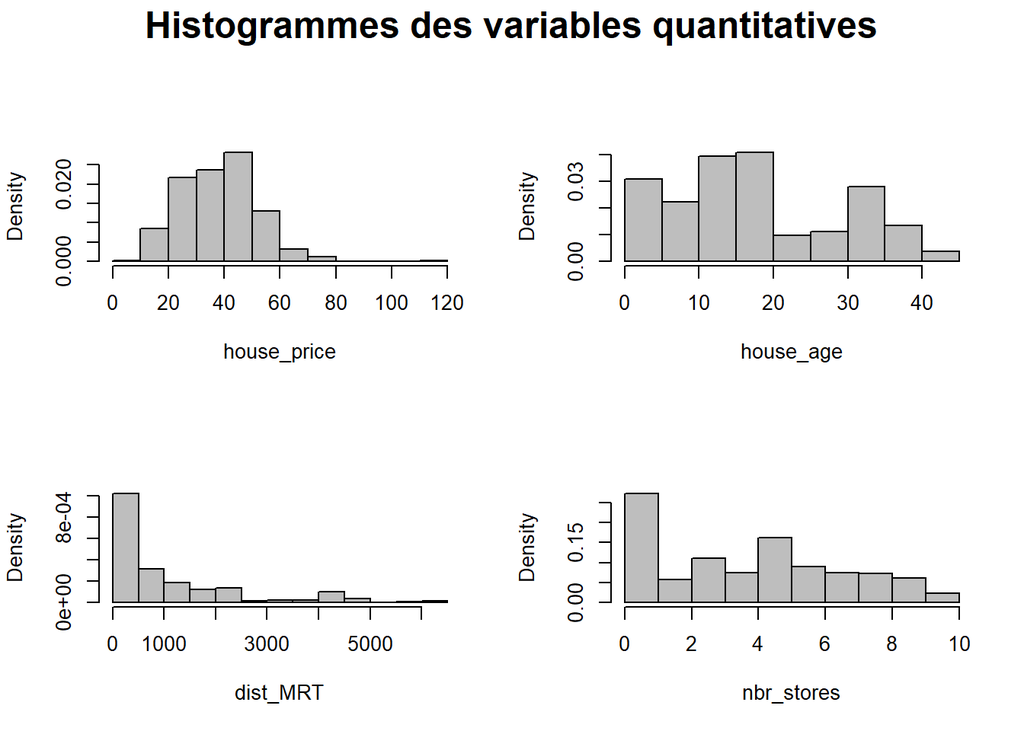

On remarque que les différentes variables quantitatives ont des distributions différentes.

## 2 Statistique descriptive des différentes variables

Pour une analyse approfondie des tendances centrales des différentes variables, nous présentons ci-dessous les statistiques descriptives de ces dernières :

```
##  transaction_year     house_age         dist_MRT         nbr_stores
##  Length:414         Min.   : 0.000   Min.   :  23.38   Min.   : 0.000
##  Class :character   1st Qu.: 9.025   1st Qu.: 289.32   1st Qu.: 1.000
##  Mode  :character   Median :16.100   Median : 492.23   Median : 4.000
##                     Mean   :17.713   Mean   :1083.89   Mean   : 4.094
##                     3rd Qu.:28.150   3rd Qu.:1454.28   3rd Qu.: 6.000
##                     Max.   :43.800   Max.   :6488.02   Max.   :10.000
##   house_price
##  Min.   :  7.60
##  1st Qu.: 27.70
##  Median : 38.45
##  Mean   : 37.98
##  3rd Qu.: 46.60
##  Max.   :117.50
```

La variable **âge du bien** a pour valeur minimum 0 et pour valeur maximum 43 ans. Sa moyenne se situe autour de 17 ans.

Aucun des biens vendus n’est à moins de 23 mètres de la station MRT la plus proche. Le bien le plus éloigné se situe à environ 6.5 km. Compte tenu de la grande dispersion de cette variable, nous allons utiliser le logarithme de cette dernière pour les analyses qui suivent.

## 3 Répartition géographique des logements

[interactive chart not shown]

Le graphique ci-dessus montre les prix au m² des logements en fonction de leur situation géographique. On remarque une concentration des logements ayant des prix au ping les plus élevés dans la même zone géographique.

## 4 Nuage de points entre les variables quantitatives et le prix du bien

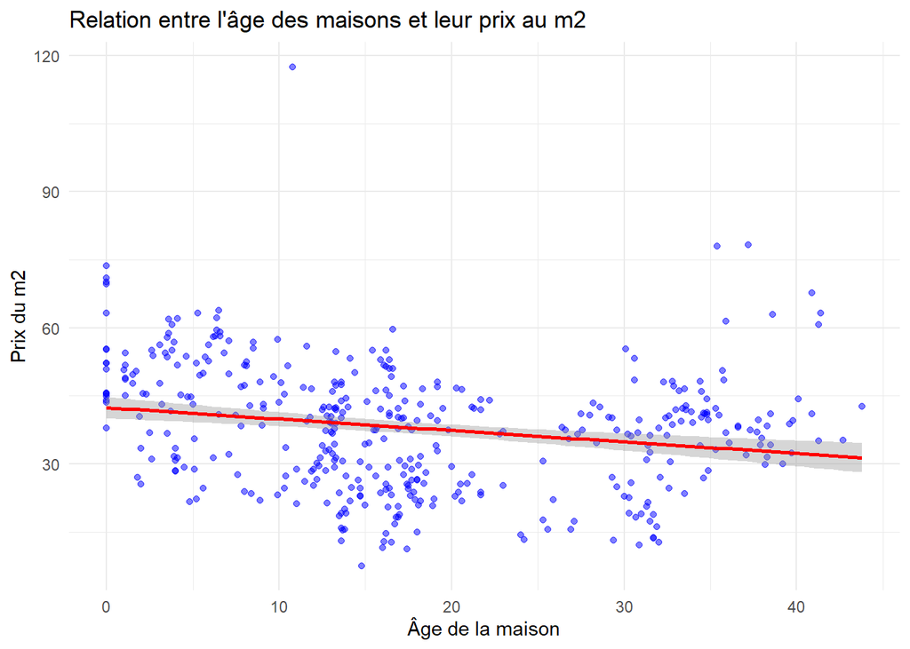

On remarque une legère baisse du prix du bien quand lâge de ce dernier évolue.

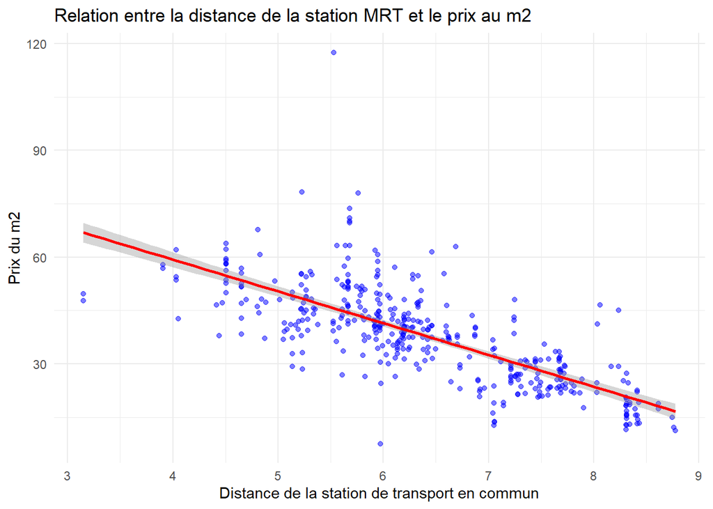

On constate une nette baisse du prix du bien quand ce dernier s’éloigne de la station MRT la plus proche.

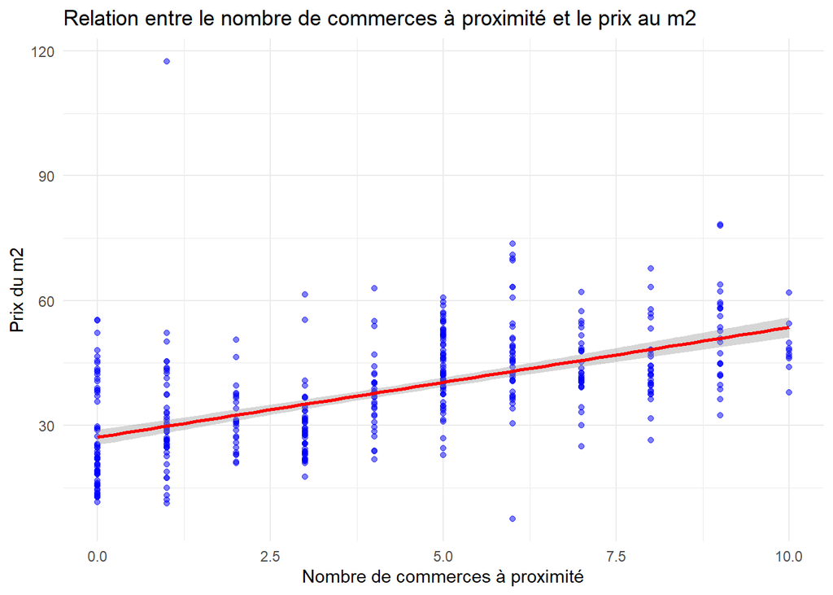

On note un lien positif entre le nombre de supérettes à proximité et le prix du bien.

## 5 Corrélation entre les variables quantitatives

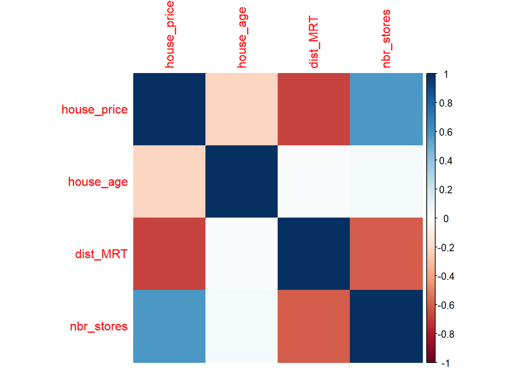

En ce qui concerne les variables explicatives, on constate une corrélation négative entre la distance de la station MRT et le nombre de commerce à proximité.

## 6 Lien entre l’année de transaction et le prix du bien

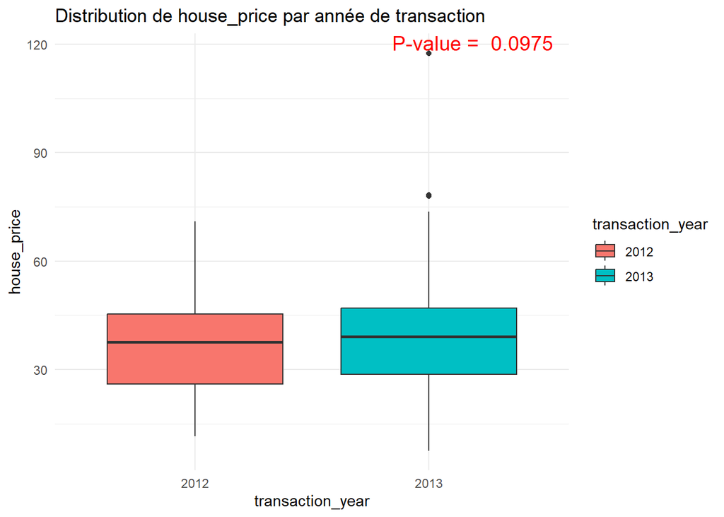

La p-value est supérieure à 5% ce qui montre que l’année de transaction ne permet pas de différencier le prix du bien.

## 7 Regression linéaire multiple

La regression linéaire entre le prix en dollar taïwandais par ping du bien et les variables explicatives $house\_price_i=\beta_0+\beta_1 house\_age_i+ \beta_2 l\_dist\_MRT_i + \beta_3 nbr\_stores_i + \beta_4 transaction\_year_i + \varepsilon_i \hspace{10pt} \forall i\in[1,N]$ donne le résultat suivant:

```
##
## Call:
## lm(formula = house_price ~ house_age + dist_MRT + nbr_stores +
##     transaction_year, data = data_std)
##
## Residuals:
##     Min      1Q  Median      3Q     Max
## -38.250  -5.519  -1.135   4.381  76.339
##
## Coefficients:
##                      Estimate Std. Error t value Pr(>|t|)
## (Intercept)           35.8837     0.8165  43.946  < 2e-16 ***
## house_age             -2.9482     0.4528  -6.511 2.19e-10 ***
## dist_MRT              -6.8118     0.5660 -12.035  < 2e-16 ***
## nbr_stores             3.8191     0.5665   6.742 5.34e-11 ***
## transaction_year2013   3.0137     0.9794   3.077  0.00223 **
## ---
## Signif. codes:  0 '***' 0.001 '**' 0.01 '*' 0.05 '.' 0.1 ' ' 1
##
## Residual standard error: 9.157 on 409 degrees of freedom
## Multiple R-squared:  0.5514, Adjusted R-squared:  0.5471
## F-statistic: 125.7 on 4 and 409 DF,  p-value: < 2.2e-16
```

Deux choix principaux ont été faits et il convient de les rappeler avant toute interprétation des résultats du modèles. Tout d’abord, pour éviter les difficultés liées à l’interprétation de variables géospatiales dans un modèle de régression linéaire multiple, nous avons choisi d’exclure les variables *longitude* et *latitude*. De plus, nous avons décidé de standardiser l’ensemble des variables explicatives pour permettre une comparaison des effets de ces dernières.

La pvalue associée au test de significativité globale de Fisher est inférieure à $2.2e-16$ donc le modèle est globalement significatif. Aussi le **R2** du modèle est de $0.5514$ donc le modèle explique 55% de la variabilité de la variable dépendante. De plus, toutes les variables explicatives ont des pvalues associées aux tests de significativité individuelle qui sont inférieures à 1% donc elles sont toutes significatives.

## 8 Vérification des hypothèses du modèle

Nous allons effectuer différents tests statistiques pour la vérification des hypothèses du modèle de régression linéaire multiple

### 8.1 Linéarité

Pour vérifier l’hypothèse de linéarité du modèle, nous allons réaliser le graphique entre les résidus du modèle et les valeurs prédites.

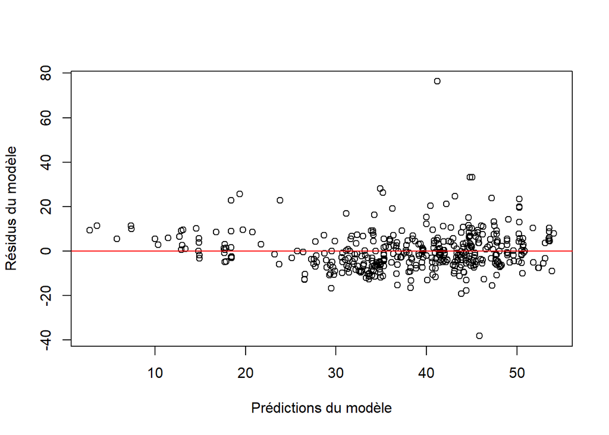

On remarque que le nuage de point est homogène et affiche une absence de pente donc on peut dire que la linéarité est respectée.

### 8.2 Test de Normalité des résidus

```
##
##  Shapiro-Wilk normality test
##
## data:  reg1$residuals
## W = 0.8833, p-value < 2.2e-16
```

La pvalue associée au test de Shapiro-Wilk est inférieure à $2.2e-16$ donc on rejette l’hypothèse nulle de normalité des résidus.

### 8.3 Test d’indépendance des résidus

Pour vérifier l’indépendance des résidus, nous allons utiliser le test de Durbin-Watson. Les hypothèses de ce test statistique sont:

- **H0**: Pas d’autocorrélation des résidus
- **H1**: Autocorrélation des résidus détectée

```
##
##  Durbin-Watson test
##
## data:  reg1
## DW = 2.117, p-value = 0.8846
## alternative hypothesis: true autocorrelation is greater than 0
```

La pvalue associée au test de Durbin-Watson est égale à $0.8846$ donc on ne rejette pas l’hypothèse nulle d’indépendance des résidus au seuil de 5%.

### 8.4 Test d’homoscédasticité des résidus

Pour vérifier l’homoscédasticité des résidus, nous allons utiliser le test de Breusch-Pagan. Les hypothèses de ce test statistique sont:

- **H0**: La variance des résidus est constante
- **H1**: La variance des résidus n’est pas constante

```
##
##  studentized Breusch-Pagan test
##
## data:  reg1
## BP = 5.9862, df = 4, p-value = 0.2002
```

La pvalue associée au test de Breusch-Pagan est égale à $0.2002$ donc on ne rejette pas l’hypothèse nulle d’homoscédasticité des résidus au seuil de 5%.

### 8.5 Test de multicolinéarité des variables

Pour vérifier l’absence de multicolinéarité dans le modèle, nous allons utiliser la **Variance Inflation Factor (VIF)**. On rejette la multicolinéarité lorsque la VIF associée à chaque variable est inférieure à **10**.

```
##        house_age         dist_MRT       nbr_stores transaction_year
##         1.009723         1.577849         1.580434         1.002660
```

La **VIF** est inférieure à 10 pour toutes les variables donc on peut conclure qu’il y a absence de multicolinéarité entre les variables explicatives du modèle.